# Curso 2 R Programming

## Generar números aleatorios según una distribuciòn

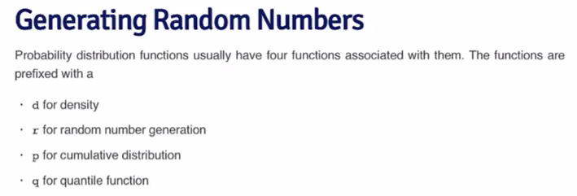

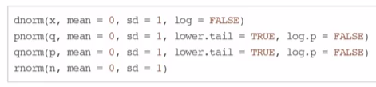

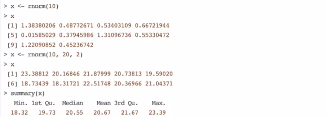

Hay que tener en cuenta que si no se cambia el seed, nos van a salir los mismos número aleatorios una y otra vez, como en este caso, al volver a poner el seed = 1 nos salen los mismos número que en la primera vez. Esto es útil si queremos reproducir un resultado, bastará con poner el mismo seed.

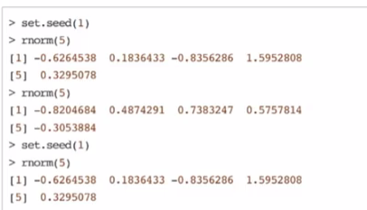

En este ejemplo generamos aleatoriamente valores con una distribución de poisson, además también calculamos la distribución acumnulada en un punto, esto es la probabilidad de que x sea igual o menor a ese valor

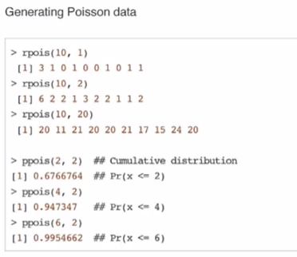

Hasta aquí lo que tenemos es la creación de valores discretos que siguen una distribución. Si queremos que sean datos lineales de manera que a un valor de x le corresponda un valor de y, tendremos que hacerlo de la siguiente manera:

Para el caso de el valor de las x tenga distribución normal:

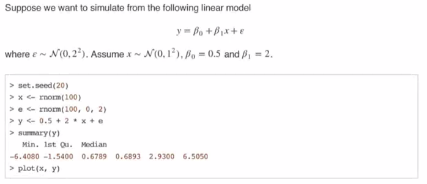

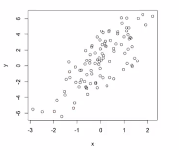

Para el caso de que el valor de las x tenga distribución binomial, por ejemplo “género”

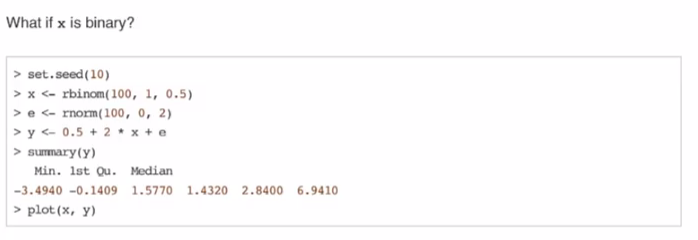

La variable x es binomial y sin embargo la variable y sigue siendo normal.

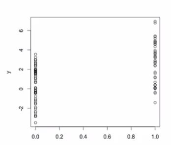

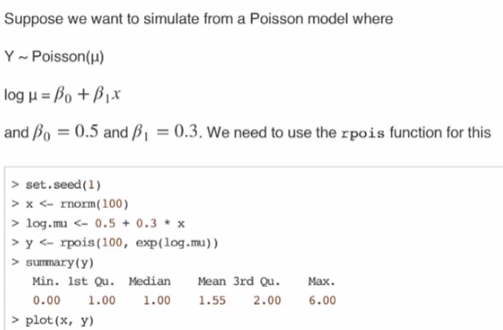

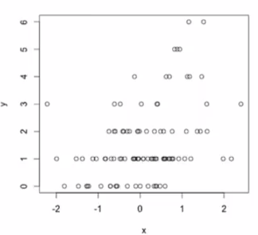

## Estructuras de control

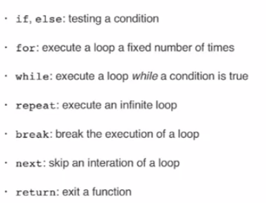

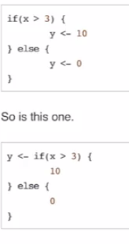

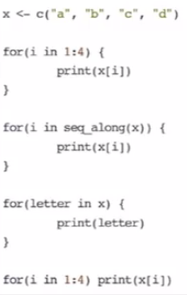

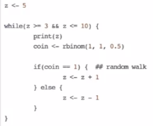

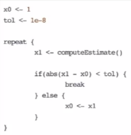

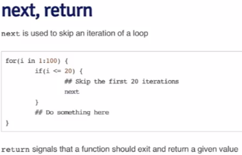

## Funciones

Devuelven lo último que se opera.

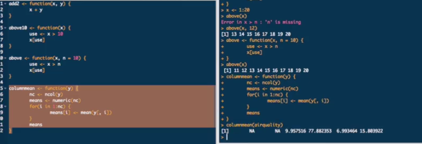

Podemos incluir parámetros para que no procese nulos, por ejemplo en la función que hemos creado para que calcule la media de todas las columnas de un dataset o matrix.

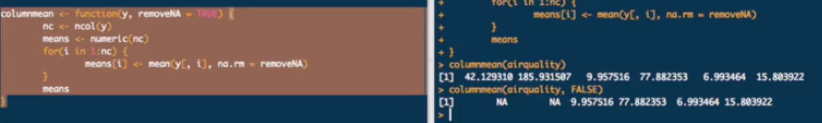

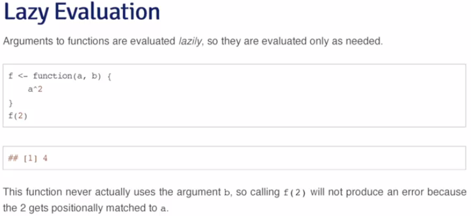

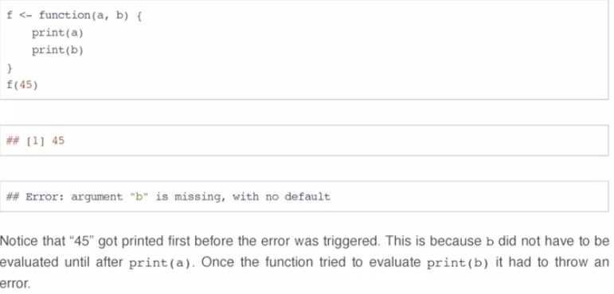

SI una función que queremos usar dentro de nuestra función tiene muchos parámetros y sólo queremos mapearlos de unos a otros se puede hacer con …

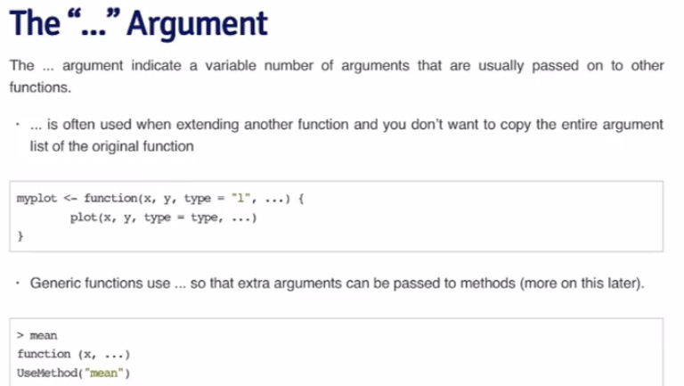

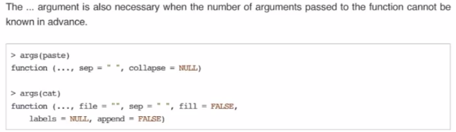

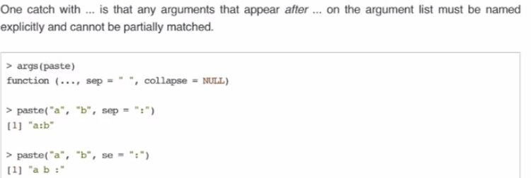

Ejemplos:

Usar función como parámetro

evaluate <- function(func, dat){

func(dat) }

Usar los puntos suspensivos para parámetros variables, función que añade start y stop a cualquier combinación de palabras que haya en medio

telegram <- function(…){ c <- paste(…,“STOP”) paste(“START”,c) }

coger ciertos parámetos por nombre dentro de los parámetros variables

mad_libs <- function(…){

args <- list(…) place <- args[[“place”]] adjective <- args[[“adjective”]] noun <- args[[“noun”]] paste(“News from”, place, “today where”, adjective, “students took to the streets in protest of the new”, noun, “being installed on campus.”) }

Crear un operador binario tipo +, que opere con lo que tenga a un lado y al otro, por ejemplo

“Hola” %p% “mundo” %p% “libre”

“%p%” <- function(left,right){ paste(left,right)

}

**Ejercicios de creación de funciones:**

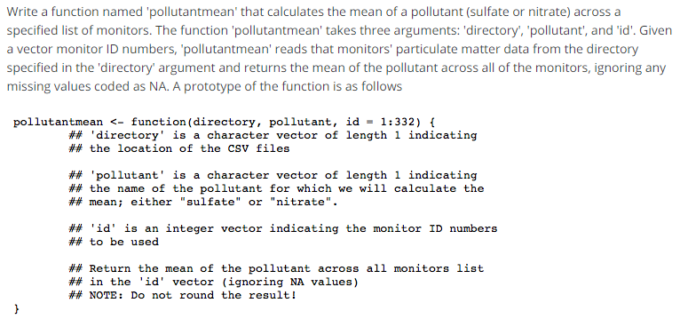

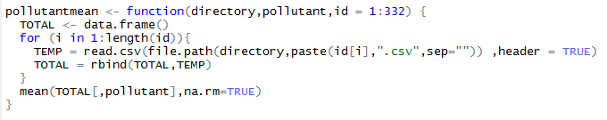

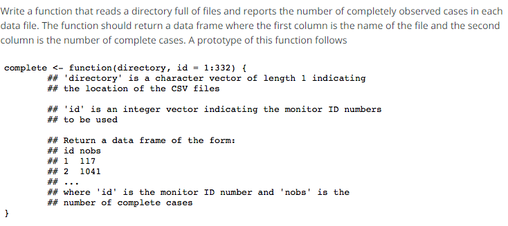

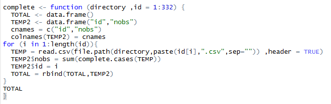

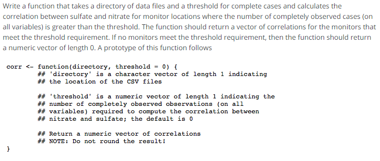

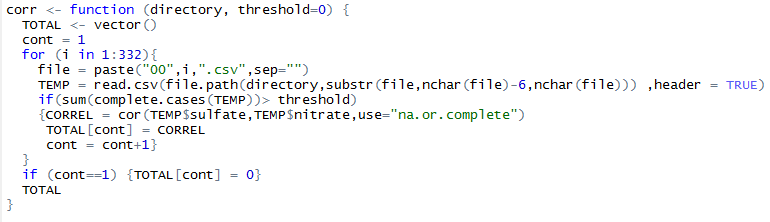

## Fechas

**FECHAS**

Las fechas en R tienen dos posibles objetos que los contengan

d1 <- as.Date(“1969-01-01”)

posixlt (el objeto contiene información adicional como segundos, dia de la semana, mes, etc)

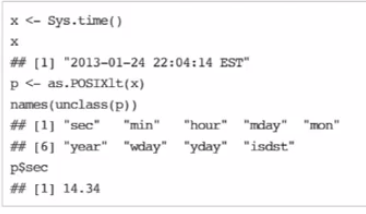

posixct sólo te da el número de segundos

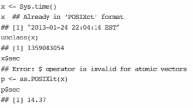

t2 <- as.POSIXlt(Sys.time())

Para sacarlo de fechas Posixct existen las funciones weekdays(), month(),etc…

difftime(Sys.time(), t1, units = ‘days’) porque por defecto nos lo devuelve en minutos

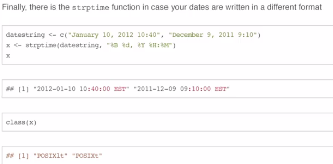

Si queremos ver el contenido interno de la variable sin pasar por la clase, hacemos unclass()

Por ejemplo una variable fecha, si la visualizo, al ser tipo fecha me la muesta con su formato, y si hacemos unclass(fecha) nos devolverá el número de días que han pasado desde 1-1-1970 que es como internamente se representa

## Bucles, lapply,mapply,sapply

**BUCLES** lapply siempre devuelve una lista, lo cual hay veces que no es lo más práctico ni eficiente.

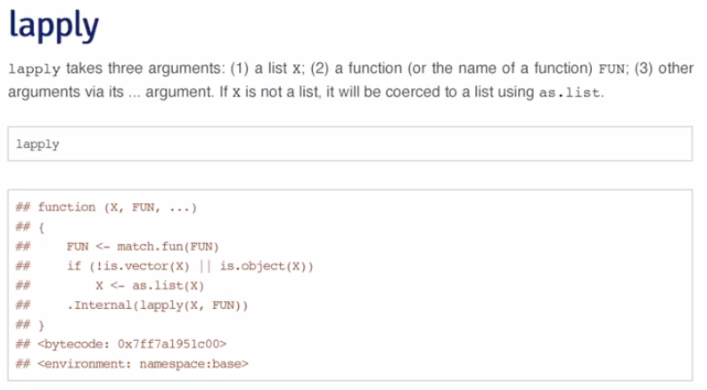

qownnotes-media-qI2776

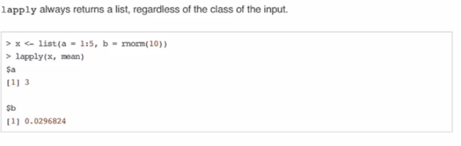

qownnotes-media-Ca2776

sapply sirve para que si todos los elementos que devuelve lapply son del mismo tipo, devolver un vector, así ganar practicidad y eficiencia

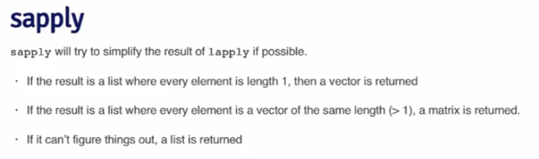

qownnotes-media-Vz2776

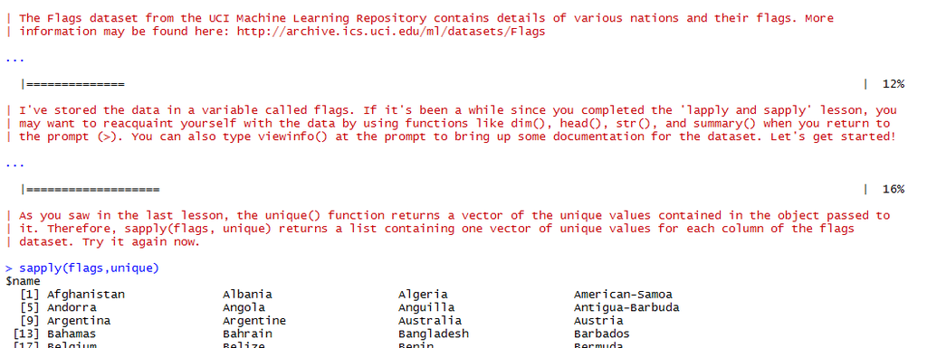

qownnotes-media-R14824

Apply por si queremos iterar sólo por las filas o sólo por las columnas de un dataframe o matrix

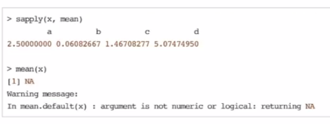

qownnotes-media-xr2776

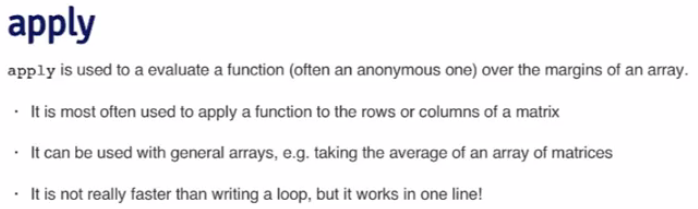

qownnotes-media-ue2776

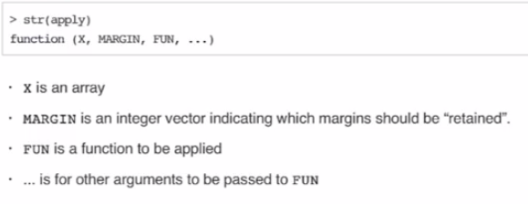

qownnotes-media-Vx2776

En el primer ejemplo se coge la segunda dimensión, en el siguiente se toma la primera dimension

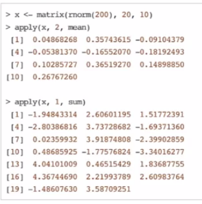

qownnotes-media-IG2776

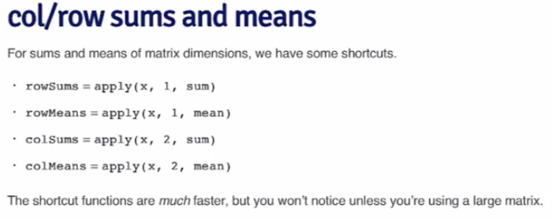

qownnotes-media-PA2776

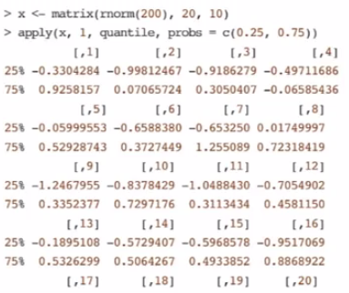

qownnotes-media-zr2776

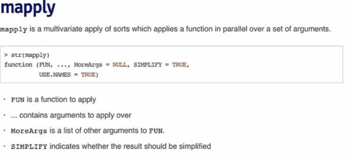

qownnotes-media-ME2776

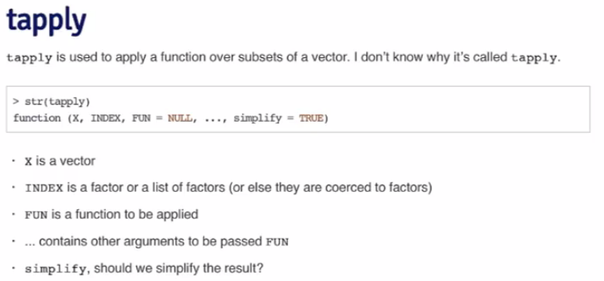

qownnotes-media-HS2776

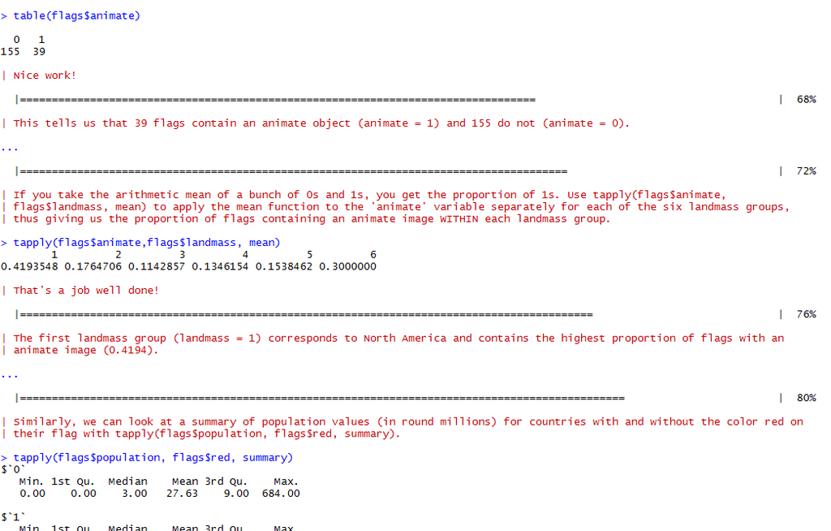

qownnotes-media-C14824

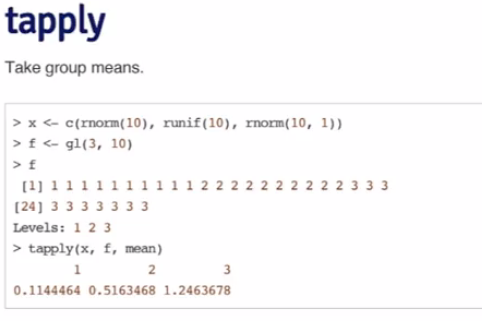

qownnotes-media-af2776

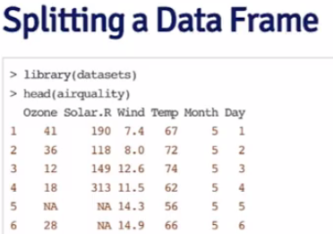

qownnotes-media-Fm2776

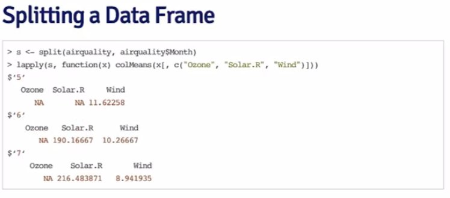

qownnotes-media-Y12084

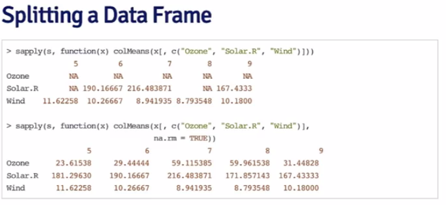

qownnotes-media-R12084

## Funciones útiles y trucos

**FUNCION STR**

Junto con summary obtenemos un resumen del contenido de los datos, sin embargo con str obtenemos toda la información sobre el continente de los datos

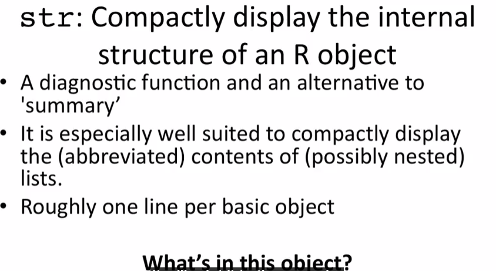

qownnotes-media-t14140

**OPTIMIZACIÓN CÓDIGO**

**TRUCOS PARA LEER TABLAS GRANDES**

read.table o read.csv:

poner comment.char = " " si no hay comentarios en el archivo.

Poner el tipo de las columnas antes para que no lo autocalcule, si se sabe a priori simplemente se añade, si no se puede hacer algo así:

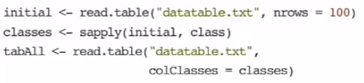

qownnotes-media-e14076

Si nos peta la memoria podemos hacer un cálculo rápido de esta manera

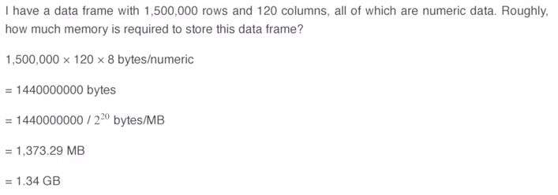

qownnotes-media-F14076

Se pueden pasar a disco y recuperar los objetos en memoria con dput y dget

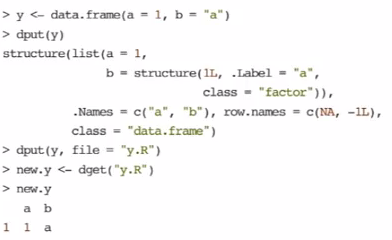

qownnotes-media-g14076

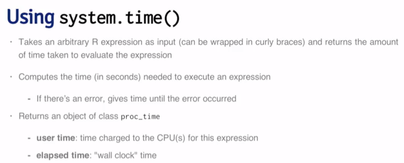

qownnotes-media-l14956

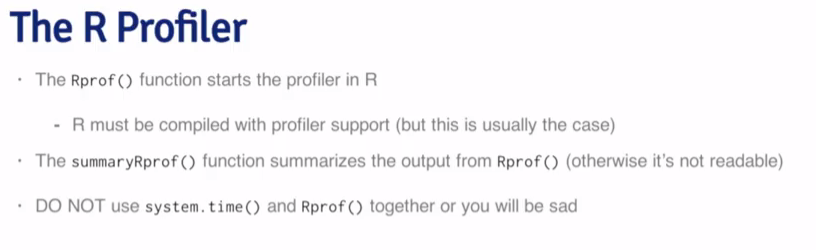

qownnotes-media-g14956

Ejemplo, con lm se hacen distintas llamadas internas a otras funciones, para saber cuánto tardan cada una:

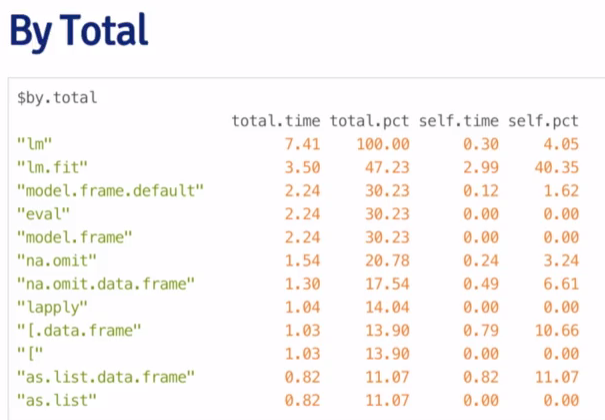

qownnotes-media-O14956

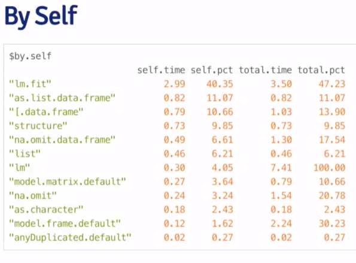

qownnotes-media-H14956

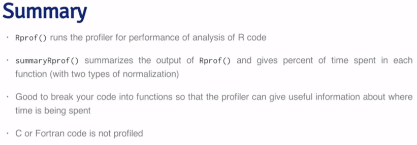

qownnotes-media-E14956

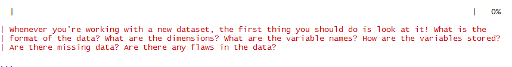

qownnotes-media-G14956

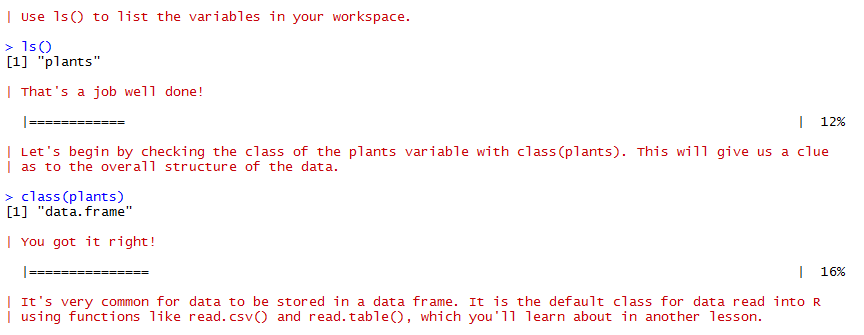

qownnotes-media-o14956

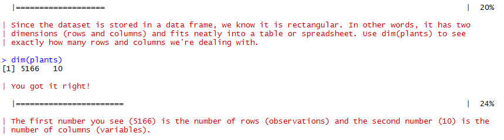

qownnotes-media-K14956